# FLARe: preliminary descriptive analyses

Thomas McGregor

2022-06-15

# Introduction

Descriptive analyses for the FLARe dataset collected as part of the PORT study.

Exclusions have not been applied and missing data has not been imputed at this stage.

# Pre-registered exclusions

The following exclusion criteria related to FLARe performance were submitted in the preregistration:

- Self-reporting that they did not follow the instructions properly for the fear conditioning task (i.e. removed their headphones, did not pay attention, were interrupted)
- Self-reporting that they did not find the aversive stimulus unpleasant (i.e. a rating of five out of ten or lower)
- Missing six or more trial ratings during the acquisition or extinction phase of the fear conditioning task
- Having an average device volume of 50% or lower during the acquisition phase of the fear conditioning task

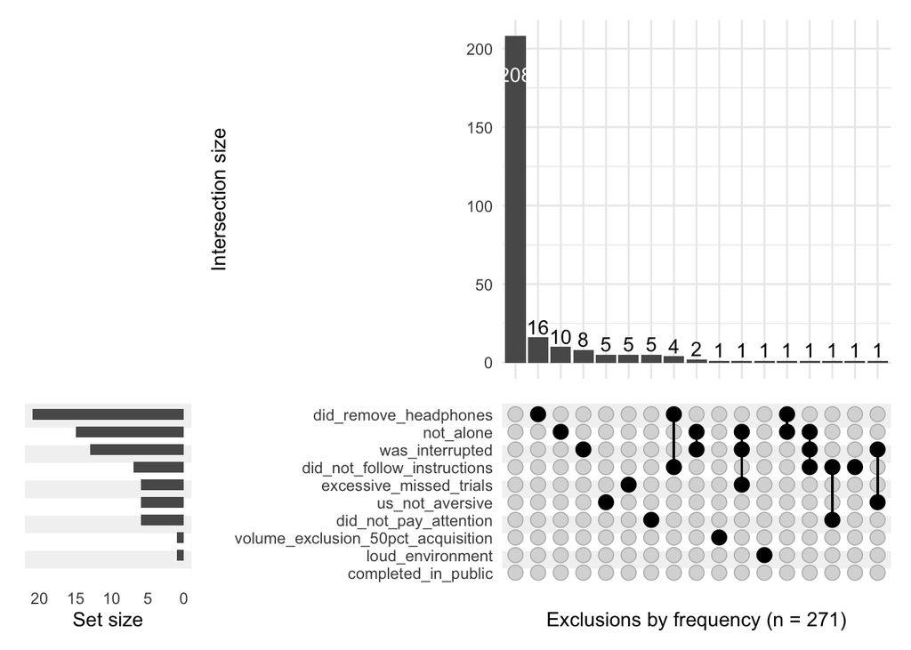

**Number of participants that self-reported each type of instructions violation**

The same participant may have reported not following more than one instruction

| Instructions violation | Number reporting |
| --- | --- |
| Did remove headphones | 21 |
| Not alone | 15 |
| Was interrupted | 13 |
| Did not follow instructions | 7 |
| Did not pay attention | 6 |
| Us not aversive | 6 |
| Excessive missed trials | 6 |
| Loud environment | 1 |
| Volume exclusion 50pct acquisition | 1 |
| Completed in public | 0 |

[figure not shown]

# Potential exclusions

List of other variables that could potentially indicate that participants did not complete the FLARe task properly:

- `rating_delay_min_flag` - Participant responded to an expectancy rating before the 3 second rating delay
- `rating_delay_max_flag` - Participant responded to an expectancy rating after the 8 second trial time
- `trial_delay_flag` - The maximum trial delay is greater than the length of two trials (22 seconds)
- `break_length_flag` - A break of 20 minutes or longer
- `fc_duration_flag` - Length of task was 40 minutes or more
- `headphones_disconnected` - Headphones disconnected at least once during the task
- `exited_app` - Exited the app at least once during the task

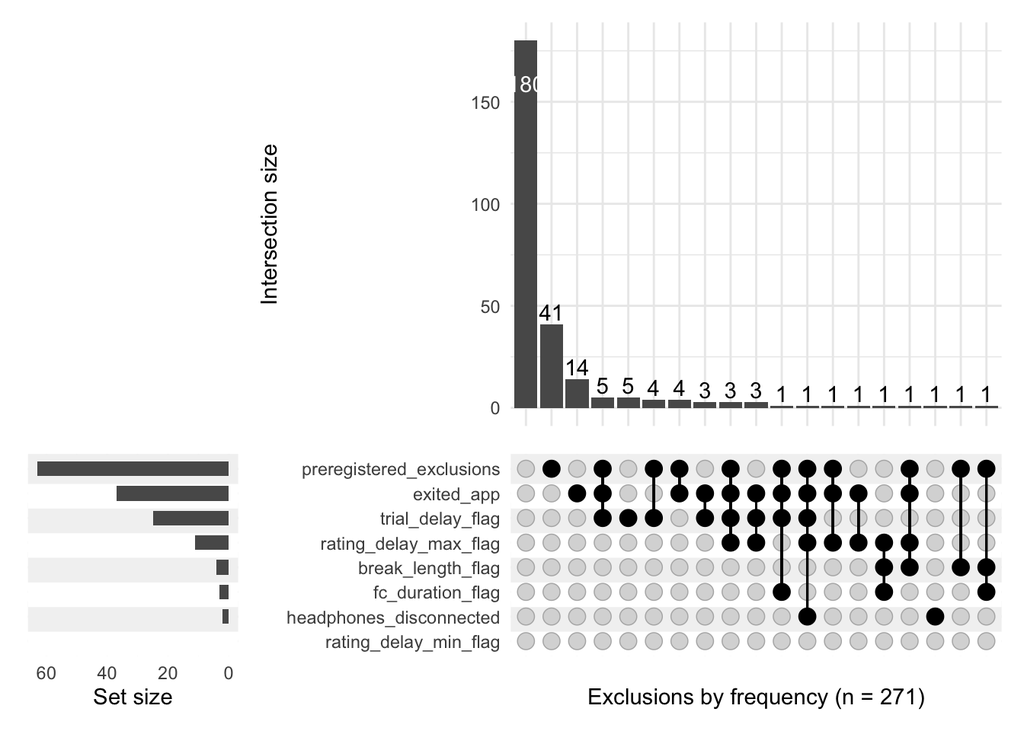

The same participant may have reported not following more than one instruction

| Instructions violation | Number reporting |
| --- | --- |
| Preregistered exclusions | 63 |
| Exited app | 37 |
| Trial delay flag | 25 |
| Rating delay max flag | 11 |
| Break length flag | 4 |
| Fc duration flag | 3 |
| Headphones disconnected | 2 |
| Rating delay min flag | 0 |

[figure not shown]

# Variable exploration

## Headphone removal

**Point at which participants self-reported removing their headphones**

| Headphones removal point | Number reporting |
| --- | --- |
| During timed trials after i had heard one loud noise | 8 |
| During timed trials after i had heard a few loud noises | 5 |
| Never during any timed trials | 5 |
| During timed trials but i hadnt heard any loud noises | 2 |
| During timed trials because i hadnt heard anything for a long time | 1 |

[figure not shown]

# Elephant plots

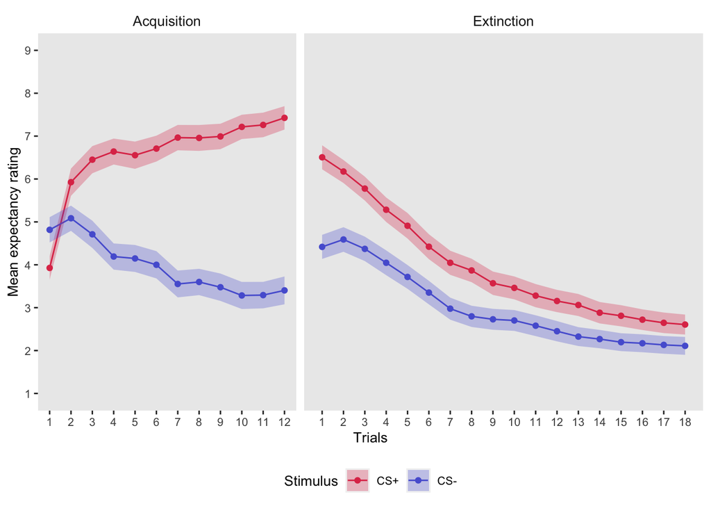

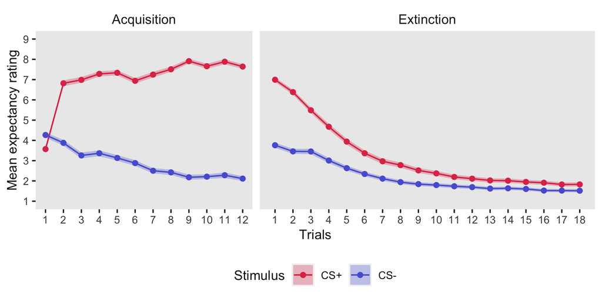

Elephant plot from McGregor et al. (2021) for comparison.